[figure not shown]

# Cálculos con variables discretas

Probabilidades puntuales, acumuladas, quantiles y generación de numeros aleatorios

[Mario Morales](https://mariomorales.xyz/)

mamorales@correo.unicordoba.edu.co

Universidad de Córdoba, Montería

14/10/2026

# Introducción

## Introducción

Estudiamos en esta clase los modelos de probabilidad asociados a las variables aleatorias discretas de uso frecuente. Definimos el modelo de Bernoulli, binomial, geométrico, binomial negativo, hipergeométrico y de Poisson, estableciendo los supuestos que deben cumplir los experimentos aleatorios que dan lugar a ellos. Al finalizar la clase el estudiante estará en capacidad de usar R para llevar a cabo el cálculo de probabilidades puntuales y acumuladas, cuantiles y generar datos pseudo aleatorios usando estos modelos.

# Funciones para modelos discretos con R

## Funciones `d`: *density*

- función `d`: *density* permite el calculo de probabilidades puntuales, es decir, con esta función se evalúa la función de probabilidad.

Por ejemplo, en el caso de la distribución binomial, `dbinom(x,n,pi)` evalúa la función
$$\binom{n}{x}\pi^{x}(1-\pi)^{(n-x)}$$

## Funciones `p`: *probability*

- función `p`: para evaluar la función de distribución del modelo definido.

Por ejemplo, en el caso binomial evalúa
$$\sum_{k=0}^x\binom{n}{k}\pi^{k}(1-\pi)^{(n-k)}$$

## Funciones `r`: *random*

Las funciones `r`: *random* se usan para generar (simular) datos pseudo aleatorios que siguen la distribución del modelo.

## Funciones `q`: *quantile*

- Las funciones `q`: *quantile* se usan para el cálculo de percentiles de la distribución.
- Este método implementa la función inversa de la `cdf`.

**Importante**

Dada una probabilidad $p$, la función `q` regresa el valor mas pequeño $x$ tal que $P(X\leq x )\ge p$.

## Modelo Binomial (I)

Un experimento aleatorio que consiste de

- $n$ repeticiones independientes de experimentos de Bernoulli,
- la probabilidad de éxito, $\pi$, de cada experimento permanece constante, se conoce como un experimento `Binomial`.
- la variable de interés es el número de éxitos en los $n$ ensayos.

## Ejemplos de experimentos Binomiales

- Lanzar tres monedas y contar el número de sellos, que consideraremos éxitos.
- Examinar 20 ratas de laboratorio después de someterlas a cierta dieta y observar si desarrollaron cáncer de estómago (éxito).
- Se someten insectos a cierta concentración de un veneno durante 30 minutos y al final, para cada uno, se registra si sobrevive (fracaso) o no (éxito).
- Se eligen 100 personas al azar del censo electoral y se registra, para cada uno si votará (éxito) o no (fracaso) por cierto candidato a un cargo de elección popular.

## Modelo Binomial (II)

En cada uno de los experimentos anteriores, nos interesa registrar el número de éxitos en los $n$ ensayos de Bernoulli. Sea $X$ la función que toma cada punto del espacio muestral del experimento y le hace corresponder el número de éxitos, necesitamos una fórmula que nos permita calcular las probabilidades asociadas a cada posible valor que toma la función.

## Modelo Binomial (III)

Suponga que se lanzan tres monedas (o una moneda tres veces) y registramos el resultado en el lado que queda hacia arriba (Cara o Sello). Consideremos la función (variable aleatoria) que asigna a cada punto del espacio muestral el número de sellos.

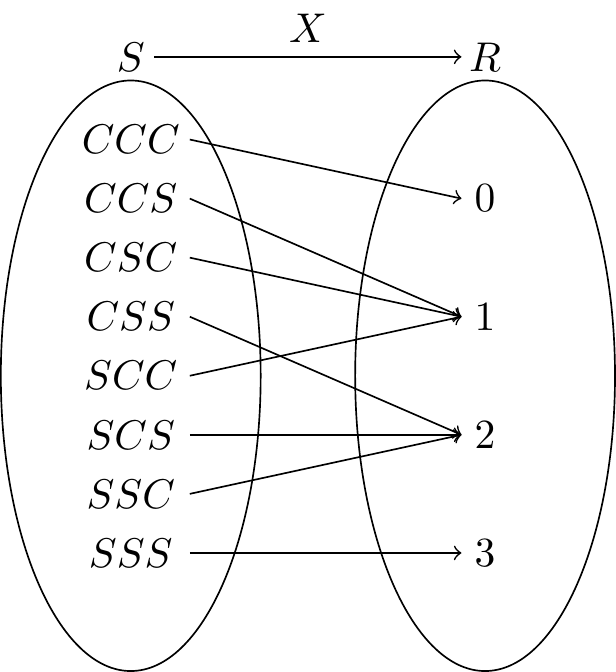

Mapeo de los resultados a la variable aleatoria X

## Modelo Binomial (V)

- Supongamos que se lanzan $n$ monedas y a cada punto del espacio muestral de este experimento hacemos corresponder el número de sellos en la cara superior, supongamos que se obtienen $x$ sellos y $n-x$ caras, con $x=0,1,2,\ldots,n$.
- Por el supuesto de independencia, sin importar la posición en que aparezcan los sellos y las caras la probabilidad de un punto con $x$ sellos y $n-x$ caras es $\pi^x(1-\pi)^{n-x}$ y hay $\tbinom{n}{x}$ formas de salir $x$ sellos, por tanto
  $$P(X=x)=\binom{n}{x}\pi^x(1-\pi)^{n-x}$$

## Modelo Binomial (VI)

- En conclusión, si $X$ es la variable aleatoria que cuenta el número de éxitos en $n$ ensayos de Bernoulli, independientes, con probabilidad de éxito constante $\pi$, su función de probabilidad esta dada por
  $$f_X(x)=P(X=x)=\begin{cases}
  \binom{n}{x}\pi^{x}(1-\pi)^{(n-x)} \text{ para } x=0,1,2,\ldots, n \\
  0 \text{ en cualquier otro } x \in R
  \end{cases}$$

## Función de distribución

La función de distribución de $X$ es

$$F_X(x)=P(X\leq x)=
\sum_{k=0}^x\binom{n}{k}\pi^{k}(1-\pi)^{(n-k)}$$

## Modelo Binomial, ejemplo con 4 monedas

Primero construiremos el espacio muestral y obtendremos los posibles valores de la variable

**Código**

```r
###0 es cara ,  1 sello
res<-expand.grid(M1=0:1,M2=0:1,M3=0:1,M4=0:1)
head(res)
```

```
  M1 M2 M3 M4
1  0  0  0  0
2  1  0  0  0
3  0  1  0  0
4  1  1  0  0
5  0  0  1  0
6  1  0  1  0
```

## Binomial 4 monedas: Valores de la variable

**Código**

```r
res$NoS<-apply(res,1,sum)
head(res)
```

```
  M1 M2 M3 M4 NoS
1  0  0  0  0   0
2  1  0  0  0   1
3  0  1  0  0   1
4  1  1  0  0   2
5  0  0  1  0   1
6  1  0  1  0   2
```

Valores de la variable No. de sellos

**Código**

```r
table(res$NoS)
```

```
0 1 2 3 4
1 4 6 4 1
```

## Binomial 4 monedas: probabilidades

- Probabilidades puntuales (estas se obtienen con `dbinom`)

**Código**

```r
table(res$NoS)/length(res$NoS)
```

```
     0      1      2      3      4
0.0625 0.2500 0.3750 0.2500 0.0625
```

## Binomial 4 monedas: acumulados

- Probabilidades acumuladas (estas se obtienen con `pbinom`)

**Código**

```r
cumsum( table(res$NoS) ) /length(res$NoS)
```

```
     0      1      2      3      4
0.0625 0.3125 0.6875 0.9375 1.0000
```

## Binomial 4 monedas: probabilidades puntuales

- Calcular la probabilidad que al lanzar 4 monedas se obtengan exactamente 2 sellos

**Código**

```r
dbinom(x=2,size = 4,prob = 1/2)
```

```
[1] 0.375
```

- Calcular todas las probabilidades puntuales $(0,1,\cdots 4)$ al lanzar 4 monedas

**Código**

```r
x=0:4
dbinom(x,size = 4,prob = 1/2)
```

```
[1] 0.0625 0.2500 0.3750 0.2500 0.0625
```

## Binomial 4 monedas: graficar la funcion de probabilidad

- Calcular todas las probabilidades puntuales $(0,1,\cdots, 4)$ al lanzar 4 monedas y guardarlas en `y`

**Código**

```r
x=0:4
y=dbinom(x,size = 4,prob = 1/2)
```

## Graficar

**Código**

```r
plot(x,y)
```

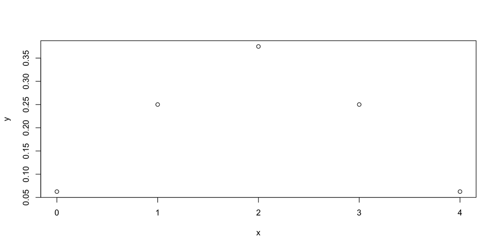

## Binomial 4 monedas: probabilidades acumuladas

- Calcular la probabilidad que al lanzar 4 monedas se obtengan 2 sellos o menos

**Código**

```r
pbinom(q=2, size = 4,prob = 1/2)
```

```
[1] 0.6875
```

## Binomial 4 monedas: probabilidades acumuladas

- Calcular todas las probabilidades acumuladas $(0,1,\cdots 4)$ al lanzar 4 monedas

**Código**

```r
x=0:4
pbinom(x,size = 4,prob = 1/2)
```

```
[1] 0.0625 0.3125 0.6875 0.9375 1.0000
```

## Binomial 4 monedas: graficar la funcion de distribucion

- Calcular todas las probabilidades acumuladas $(0,1,\cdots 4)$, se guardan en `y`

**Código**

```r
x=0:4
y=pbinom(x,size = 4,prob = 1/2)
```

## Graficar

**Código**

```r
plot(x,y)
```

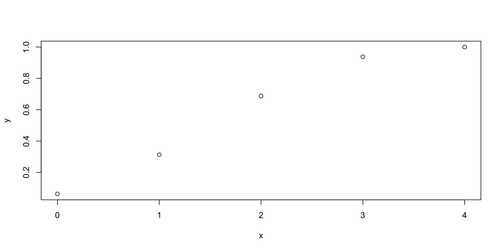

## Binomial 4 monedas: graficar la funcion de distribucion como una escalonada

- Calcular todas las probabilidades acumuladas $(0,1,\cdots 4)$, se guardan en `y`

**Código**

```r
x=pretty(-2:5,500)
y=pbinom(x,size = 4,prob = 1/2)
```